Test gratis i 3 måneder

[video not shown]

# Bookingsystem for aktiviteter. Laget av folk i bransjen selv.

Bowlinghaller, laserhaller, escape rooms, gokartbaner og trampolineparker selger tid på baner og rom – ofte flere om gangen. Luneo er bygget for akkurat det, av oss som har drevet aktivitetssenter i over ti år.

Se hva det koster [Prøv demoen](https://demo.luneo.no/backoffice/) Hva kunden får

Passer for

- Bowling
- Laserspill
- Escape room
- Gokart
- Trampolinepark
- Minigolf
- Curling
- Paintball
- Klatring
- Padel
- Golfsimulator
- Dart
- Shuffleboard
- Biljard
- VR
- Karaoke
- Lekeland

…og alle andre som selger tid på baner, rom og utstyr.

**10+ år**i aktivitetsbransjen før første linje kode ble skrevet

**850 kr**per måned eks. mva for selve bookingen. Ingen prosent av salget.

**3 mnd**gratis test for alle

**NO / EN**norsk og engelsk – for norske og engelske gjester

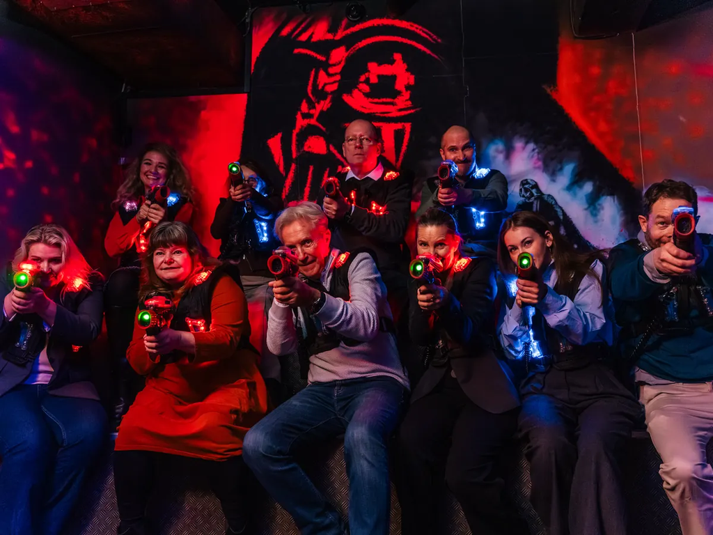

**Laserspill**Flere baner, én bestilling

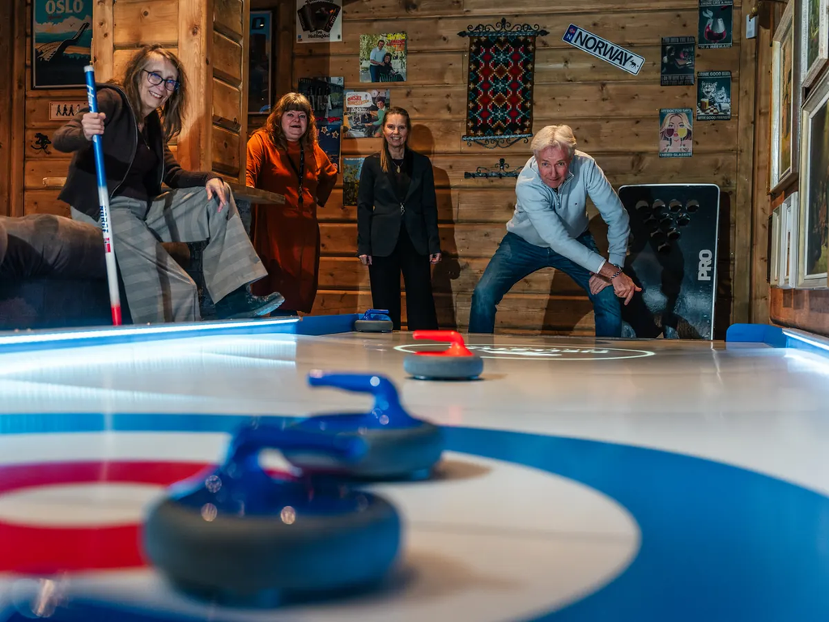

**Streetcurling**Bane og bord i samme pakke

[figure not shown]

**Gokart**Heat etter heat, uten dobbeltbooking

Hvorfor Luneo

## Vi har stått i resepsjonen selv.

Vi har drevet aktivitetssenter i Norge i over ti år. Vi har brukt de vanlige bookingsystemene, og vi vet hvor de svikter. Derfor vet vi også hva et godt bookingsystem for bransjen skal inneholde.

### Én bestilling legger beslag på flere ressurser samtidig

Åtte personer på bowling er to baner. En bursdagspakke er en bane fra 16:00 og et rom fra 17:00. Vanlige bookingsystemer klarer ikke det. Luneo tildeler ressursene selv – baner, rom, biler, brett – holder dem av og frigjør dem hvis bestillingen faller bort.

### Dere har allerede et nettsted dere er glad i

Bookingen skal kobles på det, ikke erstatte det. Luneo ligger på deres egen adresse, i deres farger og med deres navn. Ingenting av det gjesten ser bærer vårt navn.

### Mva må stemme hele veien

Hver aktivitet har sin egen sats, og i en pakke har matandelen 25 % mens resten følger aktiviteten. Det går uendret fra prislisten til betalingsvinduet til regnskapsrapporten.

Hva kunden får

## Deres eget bookingsystem, på deres egen adresse.

Kunden får **booking.deresdomene.no** eller **navn.luneo.no** – med eget navn, logo, farger og ordlyd. Det er ikke en innstilling; det er slik systemet er bygget. Tre flater følger med, på norsk og engelsk.

For gjesten

### Bookingsidene

Der gjesten bestiller, endrer og betaler – på mobil eller PC. Alle gjester får en bekreftelse på e-post med lenke til sin egen booking.

- Reservasjon
- Gavekort
- Kundeklubb
- Venteliste
- «Min side»

For de ansatte

### Backoffice

Alt personalet trenger for å styre dagen og driften. Alt kan endres av dere selv.

- Dagsplan
- Bestillinger
- Priser
- Pakker
- Rapporter

For lokalet

### Tavlen

En skjerm som viser hvem som spiller på hvilken bane nå, og hvem som er neste. Bare en nettleser på en TV – alltid tilgjengelig. QR-kode til ventelisten kan skrus av og på.

- Baneoversikt
- Neste opp
- Venteliste (valgfri)

### Gjesten styrer sin egen booking

Bekreftelsen gjesten får på e-post har en lenke til bookingen. Der kan de endre antall, legge til ekstra produkter, mat og tillegg, eller avbestille – helt til fristen dere har satt, for eksempel 48 timer før. Det blir færre telefoner i resepsjonen.

### Nettbetaling er valgfritt

Dere bestemmer selv om gjesten skal betale på nett. Skrur dere det på, kobler vi opp Dintero, og gjesten betaler slik gjesten vil – med transaksjonspriser vi har forhandlet fram. Skrur dere det av, tar dere betalt i resepsjonen når gjesten kommer, akkurat som før. Bookingen fungerer likt uansett.

- Vipps
- Kredittkort
- Klarna
- Apple Pay
- Google Pay
- m.fl.

### Faktura til bedrifter

Bedriftskunder legger inn fakturainformasjonen sin – firmanavn, organisasjonsnummer, fakturaadresse og referanse – når de bestiller. Alt ligger samlet på bestillingen, så dere enkelt kan fakturere i etterkant.

### Testet for sikkerhet av en uavhengig tredjepart

Systemet er sikkerhetstestet av en uavhengig tredjepart. Alt ligger trygt i skyen, med daglig backup, så dere ikke mister bestillinger om noe skulle skje.

### Bookingen kan bygges rett inn i nettstedet

To linjer limt inn i kundens eget nettsted, så står skjemaet midt i deres egen side – i deres farger, lyst eller mørkt, uten at gjesten forlater nettstedet. Ingen sporing, ingen informasjonskapsler. Bare nettsteder kunden selv har registrert får bygge inn bookingen.

```
<script src="https://booking.deresdomene.no/embed.js"></script>
<div data-luneo="booking"></div>
```

Prøv det selv

## Åpne demoen. Ingen registrering, ingen selger.

Et komplett aktivitetssenter: åtte bowlingbaner, to laserhaller, dart, shuffleboard, golfsimulatorer og karaoke – med bookinger, priser, pakker og folk i kø. Du kommer rett inn i backoffice og kan gjøre nøyaktig hva du vil med det.

[Åpne backoffice](https://demo.luneo.no/backoffice/) [Se hva gjesten ser](https://demo.luneo.no/reservasjon/) [Åpne tavlen](https://demo.luneo.no/tavle/)

Ting som er verdt å prøve

### Legg inn en booking

Klikk på en tom rute i dagsplanen. Systemet finner banene selv, og sier fra hvis noen andre allerede har dem.

### Dra en booking til en annen bane

Ta tak i en blokk i tidslinjen og flytt den. Den lander bare der den faktisk kan ligge.

### Se hallen som brukes til to ting

Under Ressurser står Hall 1 og Hall 2 merket «delt» – de brukes både til laserspill og innendørs paintball. Er den ene tatt, er den tatt for begge.

### Steng en bane

Legg inn et avvik under Ressurser. Er det bookinger i perioden, får du beskjed før noe lagres – med navn og telefonnummer.

### Endre en pris

Alt daglig leder kan røre, kan du røre. Gå så til bookingsiden og se at prisen har endret seg med en gang.

### Bestill som en gjest

Fyll ut reservasjonsskjemaet, og se bestillingen dukke opp i dagsplanen.

Senteret er oppdiktet. Demoen sender **ingen** e-post – bekreftelsen legges i E-post-fanen så du kan lese den slik gjesten ville fått den, og gjestens egen side åpnes fra bookingen. Alt du gjør nullstilles hver natt, så neste person møter en hel demo.

Det som gjør jobben lettere

## Bygget rundt hverdagen i et aktivitetssenter.

### Bookingen tildeler banene selv

Gjesten velger tid og antall; systemet finner ut hvor mange ressurser det blir og hvilke som er ledige. Personalet overstyrer når de vil.

### Pakker som holder av flere ting i rekkefølge

Bursdag: bane 16–17, rom 17–18. Planleggeren får alt til å gå opp og reserverer alt i ett.

### Forespørsel eller direkte booking

Deres valg, og det kan settes per pakke. Noen vil se på julebordet før de sier ja; ingen vil vurdere to personer på en bane en tirsdag.

### Norsk og engelsk

Skrevet på norsk av folk som kan bransjen – ikke oversatt. Engelske gjester får hele bookingen på engelsk.

### Alt kan endres av dere selv

Priser, åpningstider, pakker, kundegrupper, skjemafelt, tekstene gjesten leser, farger, logo. Ikke en support-sak.

### Loggen viser hvem som gjorde hva

Hver endring på en bestilling, med hvem og når.

Antall: 4 → 6 · Baner: Bane 1 → Bane 1, Bane 2

### Personopplysninger ryddes av seg selv

Gamle bestillinger arkiveres og slettes etter frister dere selv setter.

### Ingen app, ingen installasjon

Alt er nettsider som virker på mobil, nettbrett, PC og TV-en i lokalet.

### På deres eget domene

Bookingen ligger på booking.deresdomene.no hvis dere vil, og ser ut som deres nettsted.

Pris

## Én fast, lav månedspris. Ikke én krone av omsetningen.

Selve bookingen koster 850 kr i måneden eks. mva. Det er hele grunnprisen. Funksjoner utover det kjøper dere én og én, i backoffice, når dere trenger dem – og skrur dem av like enkelt.

850kr / mnd eks. mva for bookingen

**Ingen prosent av salget**

Andre tar en andel av hver bestilling. Vi tar en fast sum, uansett hvor godt det går.

**Prisen låses den dagen dere skrur på**

Prisen og vilkårene som gjaldt lagres, og kan ikke endres i ettertid uten at det synes.

**Oppsigelse er én knapp**

Funksjonen står ut måneden, så er den borte. Ingen telefon til support.

Alltid med – uten tillegg

- Omsetningsrapport

  Per dag, uke eller måned, fordelt på aktivitet og kundegruppe, med mva. Eksport til PDF og Excel.
- Venteliste

  Gjestene stiller seg i kø fra mobilen. QR-kode på tavlen kan skrus av og på.
- Ansattkontoer

  Egen konto med PIN til hver ansatt. Loggen viser hvem som gjorde hva.
- Dagens plan

  Hvem tar hvilken gruppe i dag.

Skru på det dere trenger

- Gavekort250 kr

  Selg gavekort på nettsiden og i resepsjonen. Gjesten får det som PDF på e-post og bruker koden ved bestilling.
- Tilbakemeldinger150 kr

  E-post noen dager etter besøket med tre fjes. Gul og rød krever en kommentar og havner i en egen liste med oppfølging.
- Automatisk mersalg200 kr

  E-post noen dager før besøket med utvalgte produkter og en knapp til «Min side», der gjesten legger dem til selv.
- Kapasitetsutnyttelse50 kr

  Andel av banetimene som er booket, varmekart for ukedag og klokkeslett, og hva som selger mest.
- Nyhetsbrev300 kr

  Samtykke i skjemaene, abonnentliste, en enkel byggekloss-editor og utsending i små puljer.
- Tilbud til bedrift150 kr

  Pent tilbud med logo, pris og vilkår. Banene holdes av til fristen og frigis automatisk hvis de takker nei.
- Kundeklubb300 kr

  Gjestene samler poeng på aktivitet, bruker dem ved neste bestilling og får nivåer. Navn og satser bestemmer dere selv.
- Drift og vedlikehold150 kr

  Oversikt over alt utstyr og alle rom, med historikk på hva som er gjort. Personalet melder fra om feil der og da, og saken står åpen til noen har fikset den.

+**Mangler dere noe?** Vi kan skreddersy og legge opp ønsket funksjonalitet, hvis det er noe dere føler dere mangler. Ta kontakt, så ser vi på det sammen.

Deres system

850kr / mnd

Alle priser eks. mva.

- Booking850 kr

✓ **De første 3 månedene: 0 kr.** Alle kan teste Luneo gratis i tre måneder – og dere kan få tilgang og sette opp systemet uten å ta det i bruk, bare for å se hvor ryddig det er.

Ta kontakt for å teste gratis

Funksjoner skrus av og på i backoffice av daglig leder selv. Se kjøpsvilkårene.

Slik kommer dere i gang

## Fire steg. Ingen installasjon.

### Vi setter opp bedriften

Med aktivitetene, prisene og åpningstidene deres.

### Dere velger adresse

`booking.deresdomene.no` eller `navn.luneo.no`.

### Daglig leder får en konto

Og går gjennom «Kom i gang» – fem trinn i backoffice, med en knapp på hvert.

### Bookingen kobles på nettstedet

En lenke, eller to linjer limt inn.

### Bare se, uten å ta i bruk

Systemet kan testes og settes opp uten at dere tar det i bruk. Få tilgang, klikk rundt i backoffice og se hvor ryddig og fint det er – helt uforpliktende.

### Trenger dere ny nettside også?

[Digikrutt.no](https://digikrutt.no) setter opp ny nettside for dere, med Luneo integrert sømløst fra første dag – én leverandør for nettside og booking.

Ta kontakt

## Test Luneo gratis i tre måneder.

Send oss en e-post, så setter vi opp bedriften deres og tar en gjennomgang sammen. Vil dere bare se systemet først, ordner vi det også.

### Kom i kontakt

Skriv hva slags senter dere driver og hvor mange baner eller rom dere har, så svarer vi raskt.

Ta kontakt

E-post: post@digikrutt.no Nett: luneo.no

Bookingsystemet er laget av daglig leder på [Megazone](https://www.megazone.no) i Oslo, som er en del av [Playrnorge.no](https://www.playrnorge.no). Oppsett og utvikling gjøres på kveld og i helger, da Megazone og våre andre aktivitetssentre ruller og går. Det er derfor vi kan tilby dette så rimelig. E-poster og svar vil foregå på kveldstid. Luneo driftes av [Digikrutt.no](https://digikrutt.no).